# Differential Privacy for Counts: SDSS 2022 Short Course

Joshua Snoke

2022-06-07

## Laplace Mechanism

This code will use the Laplace mechanism to perturb counts. The noisy counts released satisfy epsilon-DP.

First, we introduce a simple function to add noise according to the Laplace mechanism. The function takes two inputs. (1) The desired level of privacy loss (epsilon) and the global sensitivity (for this example we will assume this is 1). This inputs determine the scale parameter (variance) of the noise added.

```r
lap_mech <- function(rep, eps, gs) {

  # Checking for proper values
  if (any(eps <= 0)) {
    stop("The eps must be positive.")
  }
  if (any(gs <= 0)) {
    stop("The GS must be positive.")
  }

  # Calculating the scale
  scale <- gs / eps

  r <- runif(1)

  if(r > 0.5) {
    r2 <- 1 - r
    x <- 0 - sign(r - 0.5) * scale * log(2 * r2)
  } else {
    x <- 0 - sign(r - 0.5) * scale * log(2 * r)
  }

  return(x)
}

## wrapper function to make multiple draws (for multiple counts)
lap_mech_wrapper = function(n, eps, gs){
  sapply(1:n, lap_mech, eps = eps, gs = gs)
}
```

## Simulated Data Example

Now let’s load in a simulated data set of COVID cases and deaths by county. Print out the first 10 rows to get an idea of the variables.

```r
simulated_dp_data = read_csv('simulated_dp_data.csv',
                             show_col_types = FALSE) %>%
  mutate_at(vars(county, race, sex), as.factor)
print(simulated_dp_data,
      n = 10)
```

```
## # A tibble: 18,360 × 7
##    date       county race        sex   group_cases group_deaths group_population
##    <date>     <fct>  <fct>       <fct>       <dbl>        <dbl>            <dbl>
##  1 2022-01-01 1      White       Male           47            0            95798
##  2 2022-01-01 1      White       Fema…          49            0            99168
##  3 2022-01-01 1      Black       Male            1            0             1790
##  4 2022-01-01 1      Black       Fema…           1            0             1590
##  5 2022-01-01 1      American I… Male            0            0              318
##  6 2022-01-01 1      American I… Fema…           0            0              292
##  7 2022-01-01 1      Asian       Male            0            0              694
##  8 2022-01-01 1      Asian       Fema…           0            0              862
##  9 2022-01-01 1      Native Haw… Male            0            0               30
## 10 2022-01-01 1      Native Haw… Fema…           0            0               32
## # … with 18,350 more rows
```

```r
summary(simulated_dp_data)
```

```
##       date                county                                      race
##  Min.   :2022-01-01   1      :1836   American Indian or Alaskan Native  :3060
##  1st Qu.:2022-02-08   7      :1836   Asian                              :3060
##  Median :2022-03-18   23     :1836   Black                              :3060
##  Mean   :2022-03-18   30     :1836   Multirace                          :3060
##  3rd Qu.:2022-04-25   33     :1836   Native Hawaiian or Pacific Islander:3060
##  Max.   :2022-06-02   36     :1836   White                              :3060
##                       (Other):7344
##      sex        group_cases        group_deaths    group_population
##  Female:9180   Min.   :-226.000   Min.   :0.0000   Min.   :     0.0
##  Male  :9180   1st Qu.:   0.000   1st Qu.:0.0000   1st Qu.:   121.5
##                Median :   0.000   Median :0.0000   Median :   514.0
##                Mean   :   6.779   Mean   :0.0524   Mean   : 30912.1
##                3rd Qu.:   0.000   3rd Qu.:0.0000   3rd Qu.: 10419.0
##                Max.   : 754.000   Max.   :8.0000   Max.   :488270.0
##
```

We can look at total cases by county.

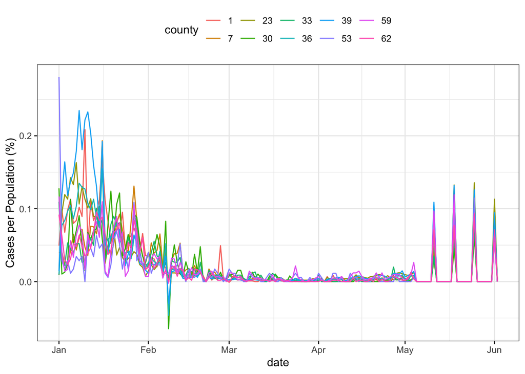

```r
simulated_dp_data %>%
  group_by(date, county) %>%
  summarize_at(vars(group_cases, group_population), sum) %>%
  ggplot(aes(x = date, y = group_cases / group_population * 100, color = county)) +
  geom_line() +
  theme_bw() +
  theme(legend.position = 'top') +
  ylab('Cases per Population (%)')
```

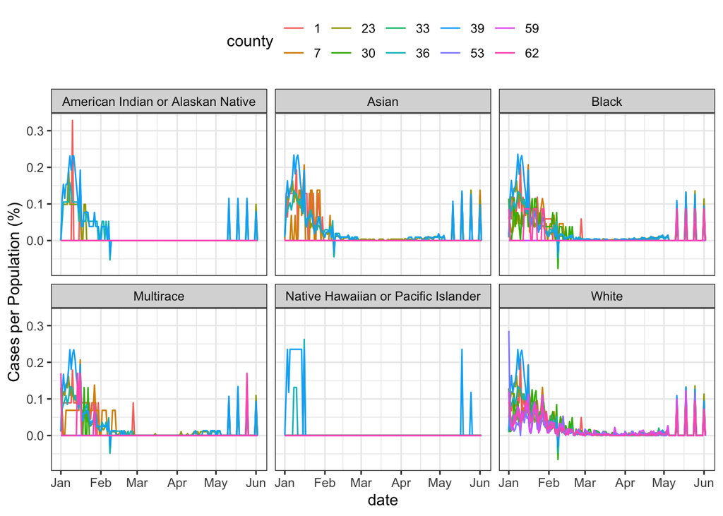

```r
## Or maybe we want to look at it broken down by race - lots of small numbers here!
simulated_dp_data %>%
  group_by(date, county, race) %>%
  summarize_at(vars(group_cases, group_population), sum) %>%
  ggplot(aes(x = date, y = group_cases / group_population * 100, color = county)) +
  geom_line() +
  facet_wrap(~race) +
  theme_bw() +
  theme(legend.position = 'top') +
  ylab('Cases per Population (%)')
```

## Adding Noise to Satisfy epsilon-Differential Privacy

Let’s add noise to the county counts for January 15th. Because each county is a disjoint subset of the data (we assume), we can use the same value of epsilon when adding noise to each count (parallel composition).

```r
noisy_counts = simulated_dp_data %>%
  filter(date == '2022-01-15') %>%
  group_by(county) %>%
  summarize_at(vars(group_cases), sum)

## We can add noise to each county count with the same epsilon because these are disjoint queries
## Epsilon = 1 and the Sensitivity = 1
noisy_counts$noisy_cases_1 = noisy_counts$group_cases + lap_mech_wrapper(nrow(noisy_counts), eps = 1, gs = 1)

## We compare the original case counts with the noisy counts
noisy_counts
```

```
## # A tibble: 10 × 3
##    county group_cases noisy_cases_1
##    <fct>        <dbl>         <dbl>
##  1 1              228         228.
##  2 7              229         229.
##  3 23             937         937.
##  4 30              80          81.4
##  5 33              67          65.1
##  6 36             766         765.
##  7 39             563         564.
##  8 53              16          15.6
##  9 59              51          50.9
## 10 62              92          92.3
```

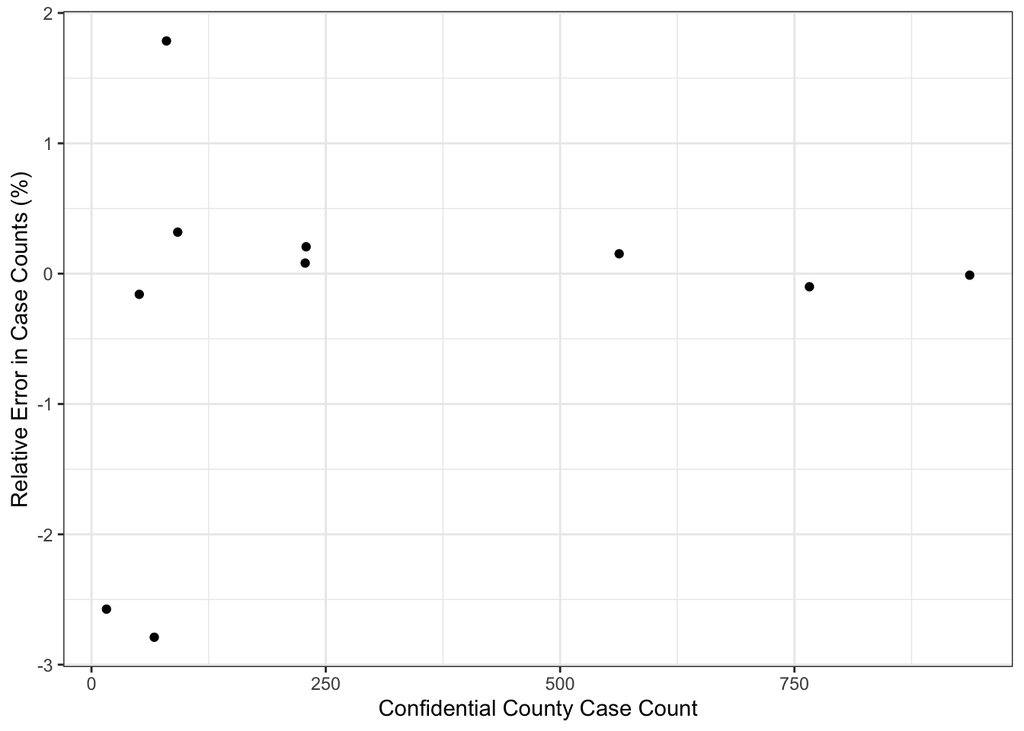

```r
## We are adding noise with the same error distribution to all counties, so we expect those with smaller counts will have more relative error
noisy_counts %>%
  ggplot(aes(x = group_cases, y = (noisy_cases_1 - group_cases) / group_cases * 100)) +
  geom_point() +
  theme_bw() +
  ylab('Relative Error in Case Counts (%)') +
  xlab('Confidential County Case Count')
```

```r
## Let's change epsilon and see how this changes the error

## Epsilon = 1
noisy_counts$noisy_cases_01 = noisy_counts$group_cases + lap_mech_wrapper(nrow(noisy_counts), eps = 0.1, gs = 1)
noisy_counts$noisy_cases_05 = noisy_counts$group_cases + lap_mech_wrapper(nrow(noisy_counts), eps = 0.5, gs = 1)
noisy_counts$noisy_cases_10 = noisy_counts$group_cases + lap_mech_wrapper(nrow(noisy_counts), eps = 10, gs = 1)

## We compare the original case counts with the noisy counts
noisy_counts
```

```
## # A tibble: 10 × 6
##    county group_cases noisy_cases_1 noisy_cases_01 noisy_cases_05 noisy_cases_10
##    <fct>        <dbl>         <dbl>          <dbl>          <dbl>          <dbl>
##  1 1              228         228.           217.           230.           228.
##  2 7              229         229.           214.           232.           229.
##  3 23             937         937.           922.           936.           937.
##  4 30              80          81.4           73.8           78.8           80.0
##  5 33              67          65.1           57.9           67.0           66.9
##  6 36             766         765.           775.           766.           766.
##  7 39             563         564.           563.           561.           563.
##  8 53              16          15.6           27.2           15.2           16.1
##  9 59              51          50.9           50.7           49.8           50.8
## 10 62              92          92.3          100.            92.5           92.0
```

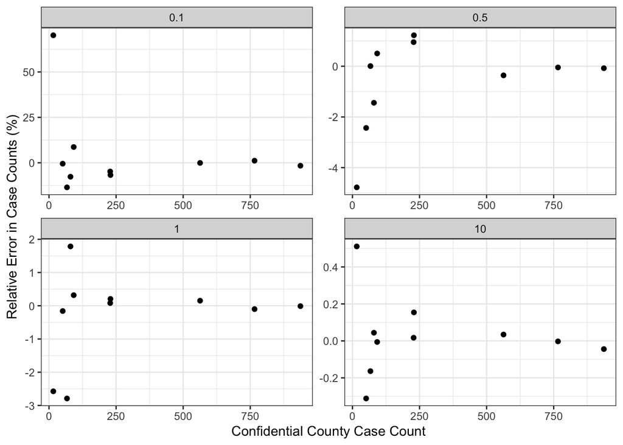

```r
## We are adding noise with the same error distribution to all counties, so those with smaller counts will have larger relative error
noisy_counts %>%
  pivot_longer(3:6, names_to = 'epsilon', values_to = 'noisy_cases') %>%
  mutate(epsilon = factor(as.numeric(recode(sub('noisy_cases_', '', epsilon),
                                           `01` = '0.1',
                                           `05` = '0.5')))) %>%
  ggplot(aes(x = group_cases, y = (noisy_cases - group_cases) / group_cases * 100)) +
  facet_wrap(~epsilon, scales = 'free') +
  geom_point() +
  theme_bw() +
  theme(legend.position = 'top') +
  scale_color_brewer(type = 'qual',
                     palette = 6) +
  ylab('Relative Error in Case Counts (%)') +
  xlab('Confidential County Case Count')
```

## Sequential Queries

Suppose now that we want to query the daily county cases over a period of a week. Because we are repeating queries on the same counties we need to split epsilon over the 7 queries (sequential composition). As before, we do not need to split epsilon across counties.

```r
noisy_counts = simulated_dp_data %>%
  filter(date >= '2022-01-15',
         date <= '2022-01-21') %>%
  group_by(county, date) %>%
  summarize_at(vars(group_cases), sum)

## We can add noise to each county count with the same epsilon because these are disjoint queries
## Epsilon = 1 (divided over seven days) and the Sensitivity = 1
noisy_counts$noisy_cases_1 = noisy_counts$group_cases + lap_mech_wrapper(nrow(noisy_counts), eps = 1 / 7, gs = 1)

## We compare the original case counts with the noisy counts
noisy_counts
```

```
## # A tibble: 70 × 4
## # Groups:   county [10]
##    county date       group_cases noisy_cases_1
##    <fct>  <date>           <dbl>         <dbl>
##  1 1      2022-01-15         228         224.
##  2 1      2022-01-16         339         384.
##  3 1      2022-01-17         226         236.
##  4 1      2022-01-18         167         171.
##  5 1      2022-01-19         116         138.
##  6 1      2022-01-20         151         153.
##  7 1      2022-01-21         172         173.
##  8 7      2022-01-15         229         230.
##  9 7      2022-01-16         491         459.
## 10 7      2022-01-17          63          61.2
## # … with 60 more rows
```

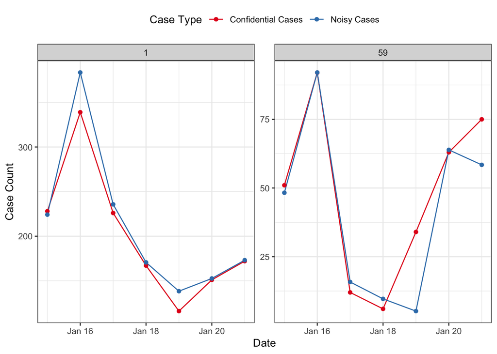

```r
## We are adding noise with the same error distribution to all counties, so we expect those with smaller counts will have more relative error
noisy_counts %>%
  filter(county %in% c('1', '59')) %>%
  pivot_longer(3:4, names_to = 'Case Type', values_to = 'Case Count') %>%
  ggplot(aes(x = date, y = `Case Count`, color = `Case Type`)) +
  geom_line() +
  geom_point() +
  facet_wrap(~county, scales = 'free') +
  theme_bw() +
  theme(legend.position = 'top') +
  scale_color_brewer(labels = c('Confidential Cases',
                                'Noisy Cases'),
                     type = 'qual',
                     palette = 6) +
  ylab('Case Count') +
  xlab('Date')
```

```r
## What is the relative error in the total counts by County over the week?
noisy_counts %>%
  group_by(county) %>%
  summarize(weekly_relative_error = (sum(noisy_cases_1) - sum(group_cases)) / sum(group_cases) * 100)
```

```
## # A tibble: 10 × 2
##    county weekly_relative_error
##    <fct>                  <dbl>
##  1 1                      5.65
##  2 7                     -4.49
##  3 23                    -0.119
##  4 30                    -7.85
##  5 33                     2.86
##  6 36                    -0.184
##  7 39                    -0.183
##  8 53                    23.8
##  9 59                   -11.9
## 10 62                     6.26
```

## Try One or More of the Following Yourself

1. Produce noisy county counts for January 15th for every racial/ethnicity and gender combination. Use a total of epsilon = 1. Should epsilon be divided?
2. Produce noisy counts for County 1 for the entire date range in the data. What total level of epsilon do you need to use for the County to have less than 10% relative error in the counts? Plot the results.
3. Produce the following noisy counts for January 15th:
1. Total counts by county
2. Female counts by county
3. Male counts by county
4. White counts by county
5. Non-White counts by county

What would you use to get these noisy counts? Use epsilon = 1, splitting it as necessary.

4. Or use your own data!